# Are Leveraged ETFs Worth It For Young Investor’s?

Trey Davidson

2025-01-05

#### Introduction

I am a young investor who is currently interested in saving for retirement. As a young investor traditional investment advise would say I can afford to take on risk as I have a long time horizon to make up losses through income generation and other methods. If I lose all of my investment at the age of 30, I am essentially equal in position to someone who starts saving money in there 30’s. [Considering the fact that 31 is the average age to start saving for retirement I wouldn’t be alone](https://news.nationwide.com/americas-retirement-voice-reveals-how-much-it-costs-to-delay-retirement/).

#### The Decesion

Since, I am less concerned about risk I have two choices when it comes to magnifying gains, I can either concentrate a portfolio or take on leverage. The issue with concentration is that many biases can come at play that make stock picking hard unlike leverage, which would allow me to keep the diversity of the S&P 500 or QQQ, while also magnifying returns.

I am going to compare leveraged ETFs to regular ETFs

Here are some leveraged ETF’s that may be included and there relevant websites for my information.

[SPY](https://www.ssga.com/us/en/intermediary/etfs/spdr-sp-500-etf-trust-spy) - Top 500 Companies US  
[QQQ](https://www.invesco.com/qqq-etf/en/home.html) - Top 100 NASDAQ companies tech weighted heavily  
[UPRO](https://www.proshares.com/our-etfs/leveraged-and-inverse/upro) - 3x Leveraged S&P 500  
[TQQQ](https://www.proshares.com/our-etfs/leveraged-and-inverse/tqqq) - 3x Leveraged QQQ  
[QLD](https://www.proshares.com/our-etfs/leveraged-and-inverse/qld) - 2x Leveraged QQQ  
[SSO](https://www.proshares.com/our-etfs/leveraged-and-inverse/sso) - 3x Leveraged S&P 500

# Comapring QQQ to QLD

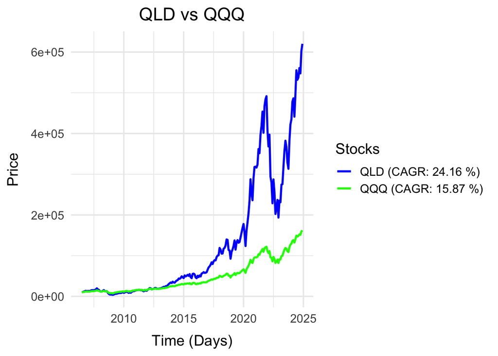

In our initial backtest, QLD (the 2x leveraged QQQ) significantly outperforms QQQ. However, before drawing any conclusions, it is crucial to assess whether these observed differences could be attributed to random chance. To determine the appropriate statistical test, we need to address two key questions:

1. Are the monthly returns independent?
2. Are the monthly returns normally distributed?

Regarding question 1, a typical approach would be to use a chi-square test to examine the independence of the returns. However, since QLD is a leveraged derivative of QQQ, we acknowledge that QLD’s performance is inherently dependent on QQQ’s returns. As such, we will account for this relationship in our analysis.

For question 2, it is important to first visualize the distribution of returns. A histogram can reveal the shape and skewness of the returns, providing insights into their distribution.

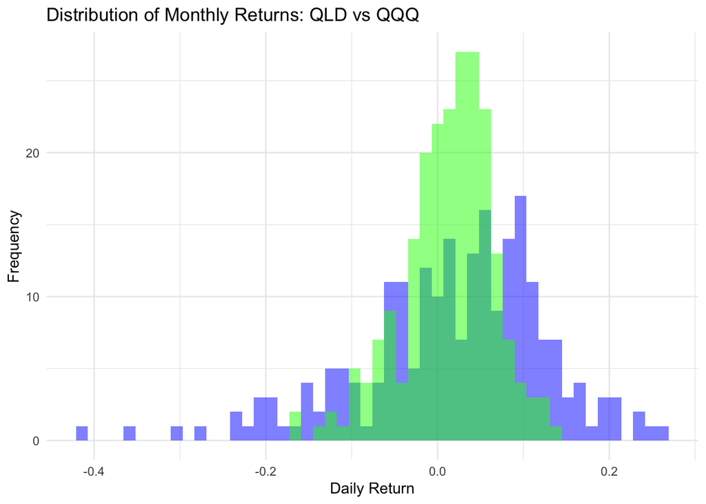

```
## QLD Test - W: 0.9645047 p-value: 2.391497e-05
```

```
## QQQ Test - W: 0.972952 p-value: 0.00029371
```

The results of the Shapiro-Wilk test confirm our visual analysis, indicating that neither of these distributions is normally distributed. Therefore, we cannot use the t-test, as it assumes normality. Instead, we will use the Wilcoxon test, which does not assume normality or independence of observations

```
## Test - W: 27551.5 p-value: 0.03141331
```

Let’s compare stock A and Stock B

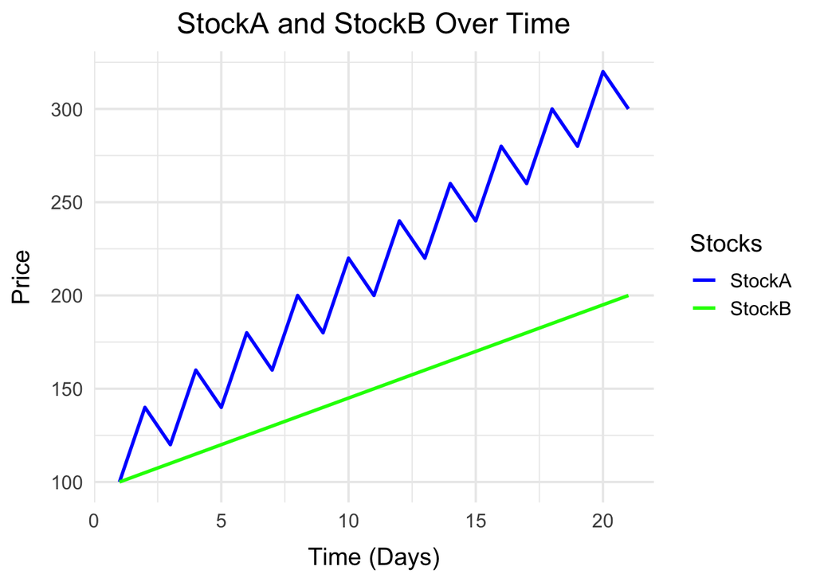

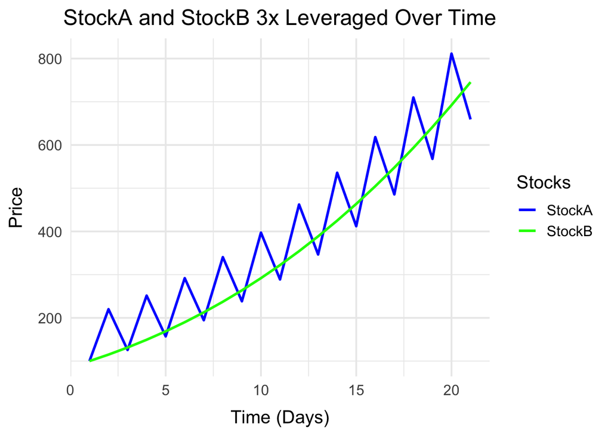

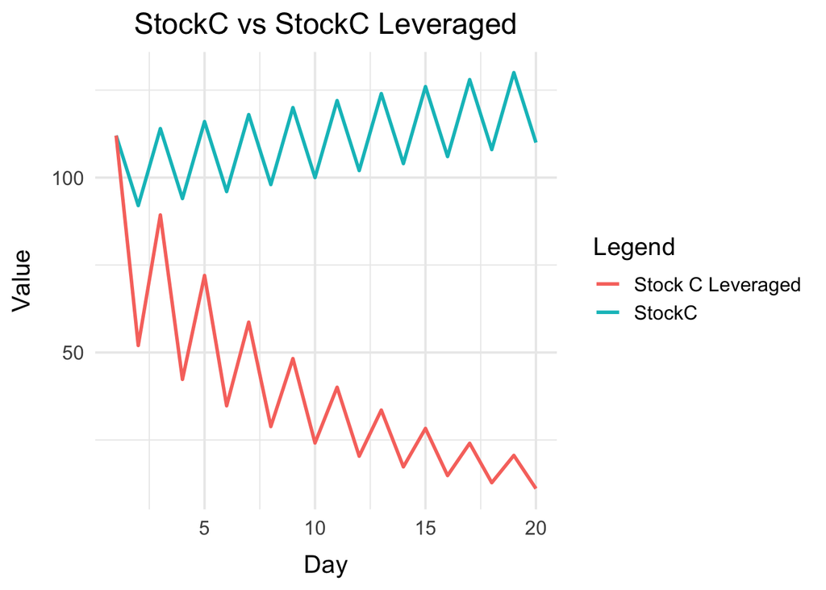